# Classification: Is the song Spanish, Korean, or Arabic?

Julia Stelman

30/9/2019

# Introduction

In this study, I look at a number of audio features of 516 songs and see if I can try to predict the language of the song’s lyrics with statistical modeling. I randomly picked three different languages to look at, each from a different language family. I use a multinomial regression approach to formulate my model. The audio features eventually used are

- Danceability (number between 0 and 1)
- Energy (number between 0 and 1)
- Loudness (number between -25 and 0)
- Speechiness (number between 0 and 1)
- Tempo (number between 50 and 250)

The languages I will be looking at today are

- Spanish
- Korean
- Arabic

Thank you to Spotify, Musixmatch, Everynoise.com, and lang-detect for the help I got from your libraries, websites, and APIs in the data collection and cleaning phase of this project, which I did in Python.

Also thank you to the R libraries quanteda, tidyverse, nnet, DescTools, caret, leaps, car, and knitr.

# Data

#### A preview of the data

|  | danceability | energy | loudness | speechiness | acousticness | liveness | tempo | lang |
| --- | --- | --- | --- | --- | --- | --- | --- | --- |
| 129 | 0.647 | 0.489 | -11.058 | 0.0330 | 0.730 | 0.131 | 94.967 | ko |
| 256 | 0.547 | 0.797 | -5.378 | 0.0472 | 0.047 | 0.193 | 139.884 | ar |
| 387 | 0.732 | 0.510 | -6.192 | 0.2600 | 0.111 | 0.102 | 87.837 | es |

# Methods

I used R to fit a multinomial regression model to the data.

#### Here is the model I ended up using

```
## Call:
## multinom(formula = lang ~ danceability + energy + loudness +
##     speechiness + tempo, data = train_ska_df)
##
## Coefficients:
##    (Intercept) danceability    energy    loudness speechiness       tempo
## es   -2.494691     2.559326   0.51073 -0.01022033   -6.880827 0.007887857
## ko    9.116123    -2.426092 -10.35331  0.39921908   -4.592110 0.012803649
##
## Residual Deviance: 685.0255
## AIC: 709.0255
```

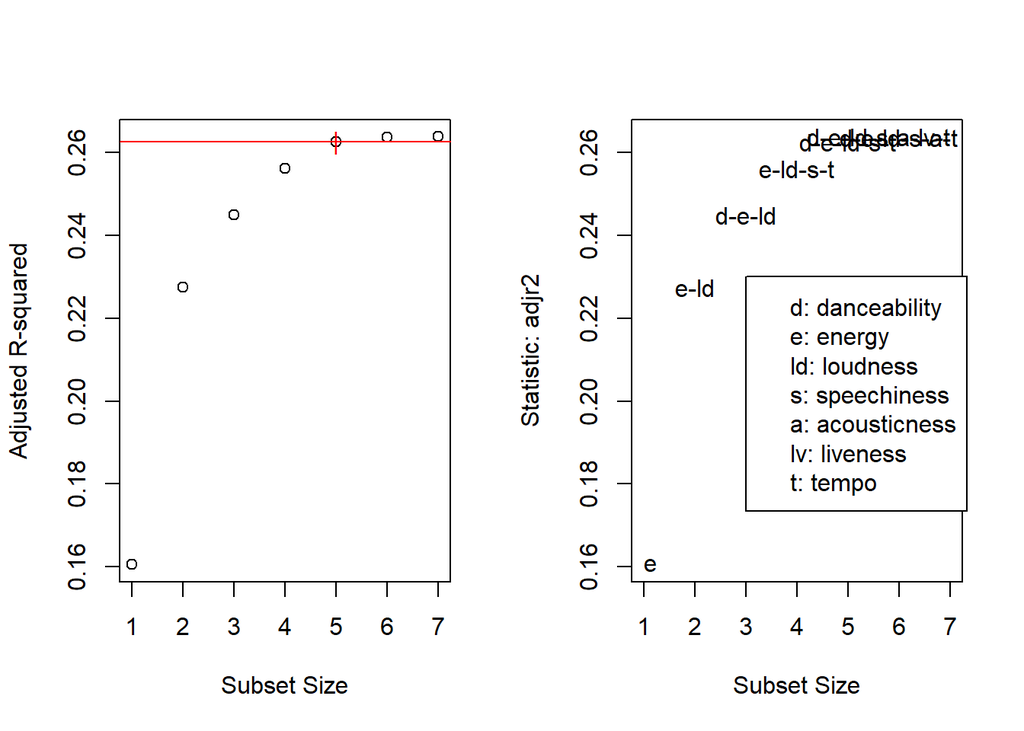

# Results

Confusion Matrix

|  | ar | es | ko |
| --- | --- | --- | --- |
| ar | 15 | 10 | 1 |
| es | 22 | 28 | 3 |
| ko | 6 | 5 | 39 |

```
##       Accuracy          Kappa  AccuracyLower  AccuracyUpper   AccuracyNull
##   6.356589e-01   4.534884e-01   5.463743e-01   7.185628e-01   3.333333e-01
## AccuracyPValue  McnemarPValue
##   2.234871e-12   3.556654e-02
```

Each person can judge for themself whether or not 63% is a good enough accuracy rate for what we want to predict, but it’s significantly better than random guessing. It’s clear that Spanish vs Arabic were confused more often than either one vs Korean. There is higher a tendency toward misclassifying arabic songs as Spanish.